# The Plan

1. Make sure you have all tools installed. mafft, trimal, iqtree at the very least.
2. Get a set of sequences to build a tree of.
3. Align these to each other.
4. Trim the alignment, removing gaps.
5. Build a fast phylogentic tree.
6. Build a thorough phylogenetic tree.

# Composing your fasta

Let's look at what we have

```bash
tree
```

```bash
inseq=1kP_LAR_orthogroup
```

```
(phylogenetics)
```

```bash
head data/$inseq.fasta
```

```
>KTWL-2000328-Kaliphora_madagascariensis
GGTGYIGKFLVEASAKAGHPTFAFAREITVSDPLKGKLVESFKNSGVTLVHGDLYDHSSL…
>QSNJ-2064790-Taiwania_cryptomerioides
KSKVLIFGATGYMGHFIAIASLDSDHPTFVFIRPSSLEDPARAQILSNLRSSGIHFITGS…
>URCP-2006931-Athyrium_filix_femina
MASKSKVLVIGATGYIGQHIAQAGPAQGHPTFVLVRPSSLSSKATLIHSFKLAGITILEG…
>ROLB-2007609-Oenothera_elata-multiple_tissue_pool
NKQRFLPSEFGNDVDRVNAVGPAKLAFGIKANIRRAIETEGIPYTYVVNNFFAGYFLPTL…
>RFSD-2005689-RFSD-Lactuca_graminifolia-2_samples_combined
EEEIALTTIKTVDDRRTLNKALIFRPPGNTLSFNEIVSIWESKIGKTLVKTYVSAEQLLKNIQEAPFGLSIELSVLHSVLVNGSSTNFDIEPSFGVEASELYPEVKYTTIDEYLT
```

```bash
grep '>' data/$inseq.fasta -c
```

```
7448
```

### Selection subsetting

this is the new route opposed to the random subsetting.

```bash
grep -o '^>[A-Z]\{4\}-' data/$inseq.fasta | cut -c 2-5 | sort |  uniq -c
```

```
     10 AALA
      5 AAXJ
      1 ABCD
     12 ABEH
      4 ABIJ
      7 ABSS
      7 ACFP
      8 ACWS
      9 ADHK
      6 AEPI
     10 AFLV
      7 AFPO
      6 AFQQ
      3 AHRN
     20 AIGO
```

[output cut: 923 more lines]

```bash
grep '^>' data/$inseq.fasta | grep -v '[A-Z]\{4\}-' | cut -c 2-6 | sort | uniq -c
```

```
     16 Ambtr
      9 Aquco
      8 Arath
      5 Betvu
      6 Carpa
      1 Chlre
      2 Chlva
     22 Elagu
     56 Eucgr
      4 Klefl
     20 Manes
      2 Micpu
      6 Mimgu
      8 Musac
     11 Nelnu
     14 Orysa
     19 Phavu
     62 Pinta
     22 Poptr
     15 Prupe
     10 Selmo
      9 Solly
      8 Sorbi
      6 Spipo
     10 Theca
     21 Vitvi
```

```bash
mkdir data/LAR_orthogroup_selection_v1
```

Using the codes above, and the online sample list of the 1kPlants project, I made an overview table containing extra information about the samples to

1. choose a balanced proporties of different major clades
2. annotate the tree afterwards

the summary looks like this:

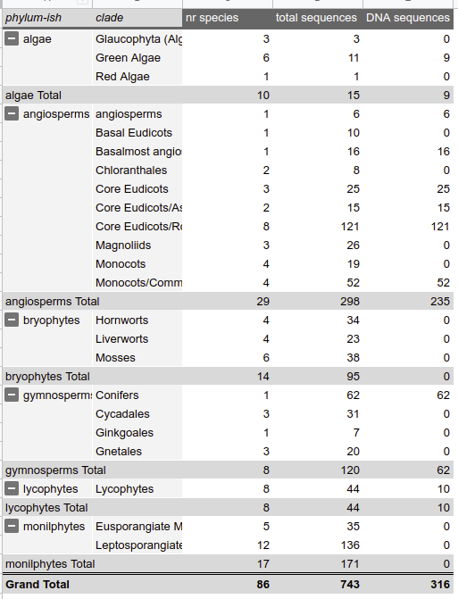

And the full table is online here: https://docs.google.com/spreadsheets/d/1v2igxY_nr7ETMoUdbqpY0QKVxJ-KYiRiO2lLoyOABsw/edit?usp=sharing

I made a selection in

`./data/LAR_orthogroup_selection_v1/1kP_LAR_RNAselection`

and

`./data/LAR_orthogroup_selection_v1/1kP_LAR_DNAselection`

then there is Erbils guide v4

`./data/Erbilsguide_v3.fasta` supplemented with `./data/Erbils_verified_sequences_v2_nonredundantwithv3.fasta`

, and extra Azolla sequences.

`Azfi PIP-likes V1.txt` & `Azfi PIP-likes V2.txt`

```bash
ls data -l
```

```
total 2812
-rw-rw-r-- 1 laura laura 2132281 May  4 21:27  1kP_LAR_orthogroup.fasta
-rw-rw-r-- 1 laura laura   21727 May  5 10:40  1kP_LAR_orthogroup_manual-selection-1.fasta
-rw-rw-r-- 1 laura laura       0 May  5 10:42  1kP_LAR_orthogroup_manual-selection-1_guidev4cat
-rw-rw-r-- 1 laura laura   40650 May  5 10:44  1kP_LAR_orthogroup_manual-selection-1_guidev4.fasta
-rw-rw-r-- 1 laura laura    2832 May  5 10:38  1kP_LAR_orthogroup_manual-selection-1.txt
-rw-rw-r-- 1 laura laura  187401 May  4 21:27  1kP_LAR_orthogroup_random700.fasta
-rw-rw-r-- 1 laura laura  194663 May  1 17:21  1kP_LAR_orthogroup_random700_guidev3.fasta
-rw-rw-r-- 1 laura laura  225247 May  5 10:42  1kP_LAR_orthogroup_random700_guidev4.fasta
-rw-rw-r-- 1 laura laura   23808 May  1 17:20  1kP_LAR_orthogroup_random700.txt
drwxrwxr-x 2 laura laura    4096 May  5 10:45  alignments_raw
drwxrwxr-x 3 laura laura    4096 May  5 10:45  alignments_trimmed
-rw-r--r-- 1 laura laura    1789 May  7 11:44 'Azfi PIP-likes V1.txt'
-rw-r--r-- 1 laura laura    3618 May  7 11:44 'Azfi PIP-likes V2.txt'
-rw-rw-r-- 1 laura laura   12902 May  1 16:54  Erbils_guide_v3.fasta
-rw-rw-r-- 1 laura laura    6018 May  4 21:59  Erbils_verified_sequences_v2_nonredundantwithv3.fasta
```

Now let's compose a fasta combining all these subsets.

```bash
grep -f ./data/LAR_orthogroup_selection_v1/1kP_LAR_DNAselection data/$inseq.fasta | grep '^>' > ./data/LAR_orthogroup_selection_v1/1kP_LAR_selection.names
grep -f ./data/LAR_orthogroup_selection_v1/1kP_LAR_RNAselection data/$inseq.fasta | grep '^>' >> ./data/LAR_orthogroup_selection_v1/1kP_LAR_selection.names
```

```
(phylogenetics) (phylogenetics)
```

```bash
grep '>' -c ./data/LAR_orthogroup_selection_v1/1kP_LAR_selection.names
grep '>'    ./data/LAR_orthogroup_selection_v1/1kP_LAR_selection.names | sort | uniq | wc -l
```

```
743
(phylogenetics) 743
(phylogenetics)
```

```bash
head  ./data/LAR_orthogroup_selection_v1/1kP_LAR_selection.names
```

```
>Pinta_v2_0-PITA_000013176_RA-Pinus_taeda
>Pinta_v2_0-PITA_000002308_RA-Pinus_taeda
>Aquco_v1_1-Aquca_022_00106_1-Aquilegia_coerulea
>Klefl_v1_0-kfl00402_0160-Klebsormidium_flaccidum
>Manes_v4_1-cassava4_1_029219m-Manihot_esculenta
>Pinta_v2_0-PITA_000022482_RA-Pinus_taeda
>Sorbi_v2_1-Sobic_008G106800_1-Sorghum_bicolor
>Poptr_v3_0-Potri_001G133200_1-Populus_trichocarpa
>Aquco_v1_1-Aquca_010_00523_1-Aquilegia_coerulea
>Pinta_v2_0-PITA_000093978_RA-Pinus_taeda
(phylogenetics)
```

```bash
rm ./data/LAR_orthogroup_selection_v1/1kP_LAR_selection_v1.fasta 2> /dev/null
/opt/rnaseq/bin/extract_sequence_by_id.pl --ID=./data/LAR_orthogroup_selection_v1/1kP_LAR_selection.names \
                                          --fileformat=fasta \
                                          --sequences=data/$inseq.fasta \
                                          --outfile=./data/LAR_orthogroup_selection_v1/1kP_LAR_selection_v1.fasta
```

```
(phylogenetics) (phylogenetics)
```

```bash
grep '>' ./data/LAR_orthogroup_selection_v1/1kP_LAR_selection_v1.fasta | sort | wc -l
grep '>' ./data/LAR_orthogroup_selection_v1/1kP_LAR_selection_v1.fasta | sort | uniq | wc -l
```

```
743
(phylogenetics) 743
(phylogenetics)
```

Now we have our fasta with the selected kP sequences, let's add extra Azolla and guide sequences.

```bash
cat ./data/Erbils_guide_v3.fasta \
    ./data/Erbils_verified_sequences_v2_nonredundantwithv3.fasta \
   './data/LAR_orthogroup_selection_v1/Azfi PIP-likes V1.txt' \
   './data/LAR_orthogroup_selection_v1/Azfi PIP-likes V2.txt' | grep '>' | sort | uniq -c
```

```
      1 >Afi_v2_s1241G000080.2 (IFR)
      1 >Afi_v2_s1241G000100.1 (PCBER)
      1 >Afi_v2_s1241G000110.6 (PCBER)
      1 >Afi_v2_s1281G000010.2 (IFR)
      1 >Afi_v2_s1281G000030.1 (PCBER)
      1 >Afi_v2_s19G000320.3 (no BLAST result)
      1 >Afi_v2_s22G002760.1 (divinyl chlorophyllide a 8-vinyl-reductase)
      1 >Afi_v2_s74G000210.2 (characterized LAR)
      1 >Afi_v2_s74G000210.2 (PCBER)
      1 >Azfi_s0004.g008890 (no BLAST result)
      1 >Azfi_s0056.g034071 (divinyl chlorophyllide a 8-vinyl-reductase)
      1 >Azfi_s0197.g057377 (characterized LAR)
      1 >Azfi_s0435.g069924 (no BLAST result)
      1 >Azolla filiculoides LAR
      1 >Chlamydomonas reinhardtii PLR-like (379876)
```

[output cut: 51 more lines]

```bash
cat ./data/Erbils_guide_v3.fasta \
    ./data/Erbils_verified_sequences_v2_nonredundantwithv3.fasta \
   './data/LAR_orthogroup_selection_v1/Azfi PIP-likes V1.txt' \
   './data/LAR_orthogroup_selection_v1/Azfi PIP-likes V2.txt' > ./data/LAR_orthogroup_selection_v1/1kP_LAR_guide_v5.fasta
```

```
(phylogenetics)
```

```bash
cat ./data/LAR_orthogroup_selection_v1/1kP_LAR_guide_v5.fasta \
    ./data/LAR_orthogroup_selection_v1/1kP_LAR_selection_v1.fasta \
    > ./data/1kP_LAR_selectionv1_guide_v5.fasta
inseq=1kP_LAR_selectionv1_guide_v5
echo $inseq
```

```
(phylogenetics) (phylogenetics) 1kP_LAR_selectionv1_guide_v5
(phylogenetics)
```

```bash
grep '>' data/$inseq.fasta -c
```

```
808
(phylogenetics)
```

### random subsetting

Skipping this section for now

```bash
n=700
grep '>' data/$inseq.fasta | tr -d '>' | shuf | head -n $n > data/"$inseq"_random"$n".txt
```

```bash
grep '>'  ../LAR_tree/alignments_raw/LAR_orthogroup_LARselectionExtraFernsAndLycophytes_guide2_aligned-mafft-linsi.fasta | tr -d '>' | tail -n +49 > data/"$inseq"_random"$n".txt
```

```bash
wc -l ./data/"$inseq"_random700.txt
```

Let's add all Azolla stuff in there, but first see what is there already

```bash
grep -i azolla data/"$inseq"_random"$n".txt
```

```bash
grep -i azolla data/"$inseq".fasta
```

Remove double guide sequence AZOLLAFILICULOIDES

```bash
sed -i '/AZOLLAFILICULOIDES/d' data/"$inseq".fasta
```

```bash
head data/"$inseq"_random"$n".txt
```

```bash
/opt/rnaseq/bin/extract_sequence_by_id.pl --ID=<(sort data/"$inseq"_random"$n".txt | uniq) \
                                          --fileformat=txt \
                                          --sequences=<(cat data/$inseq.fasta | tr -d '.')\
                                          --outfile=data/"$inseq"_random"$n".fasta
```

```bash
grep '>' -c data/"$inseq"_random"$n".fasta
```

```bash
n=700
grep -i azolla data/"$inseq"_random"$n".fasta
```

```bash
ls data
```

```bash
head data/1kP_LAR_orthogroup_random700.fasta
```

```bash
head data/Erbils_guide_v3.fasta
```

```bash
grep '>' data/Erbils_verified_sequences_v2_nonredundantwithv3.fasta
```

```bash
grep '>' data/Erbils_guide_v3.fasta
```

```bash
cat data/Erbils_guide_v3.fasta > data/1kP_LAR_orthogroup_random700_guidev4.fasta
```

```bash
cat data/Erbils_verified_sequences_v2_nonredundantwithv3.fasta >> data/1kP_LAR_orthogroup_random700_guidev4.fasta
```

```bash
echo "\n" >> data/1kP_LAR_orthogroup_random700_guidev4.fasta
```

```bash
cat data/1kP_LAR_orthogroup_random700.fasta >> data/1kP_LAR_orthogroup_random700_guidev4.fasta
```

```bash
grep '>' -c ./data/1kP_LAR_orthogroup_random700_guidev4.fasta
```

```bash
inseq="$inseq"_random"$n"_guidev4
echo $inseq
```

```bash
head data/$inseq.fasta
```

```
>Ocimum tenuiflorum EGS (AOC97444)
MEENGMKSKILIFGGTGYIGNHMVKGSLKLGHPTYVFTRPNSTKTALLNEFQSMGAIIVKGEMGEHEKLV
RLMKKVDVVISAVAIPQVLEQLKIVEAIKVAGNIKRFLPSDFGVEEDRISALPPFEACIEKKRIIRRAIE
EANIPYTYVSANCFASYFINYLLHPSDPKDEITVYGTGEVKFAMNYEQDIGLYTIKVATDPRTLNRVVIY
RPSTNITTQLELISKWEKKIGRNFKKIHIPEEEIVALTKELPEPENIPVAILHCVFIKGVTMSYDFKEND
VEASTLYPELKFTTIDELLDIFLHDPPPPASAAF

>Clarkia breweri IGS (ABR24112)
MEKIIIYGGTGYIGKFMVRASLSFSHPTFIYARPLTPDSTPSSVQLREEFRSMGVTIIEGEMEEHEKMVS
VLRQVDVVISALSVPMYPSQLLIIDAIKAAGNIKRFLPSEFGSEEDRIKPLPPFESVLEKKRIIRRAIEA
(phylogenetics)
```

# Aligning

### Either run everything one by one...

First with MAFFT

```bash
mafft --help
```

```
------------------------------------------------------------------------------
  MAFFT v7.455 (2019/Dec/7)
  https://mafft.cbrc.jp/alignment/software/
  MBE 30:772-780 (2013), NAR 30:3059-3066 (2002)
------------------------------------------------------------------------------
High speed:
  % mafft in > out
  % mafft --retree 1 in > out (fast)

High accuracy (for <~200 sequences x <~2,000 aa/nt):
  % mafft --maxiterate 1000 --localpair  in > out (% linsi in > out is also ok)
  % mafft --maxiterate 1000 --genafpair  in > out (% einsi in > out)
  % mafft --maxiterate 1000 --globalpair in > out (% ginsi in > out)

If unsure which option to use:
  % mafft --auto in > out

--op # :         Gap opening penalty, default: 1.53
--ep # :         Offset (works like gap extension penalty), default: 0.0
--maxiterate # : Maximum number of iterative refinement, default: 0
--clustalout :   Output: clustal format, default: fasta
--reorder :      Outorder: aligned, default: input order
--quiet :        Do not report progress
--thread # :     Number of threads (if unsure, --thread -1)
--dash :         Add structural information (Rozewicki et al, submitted)
(phylogenetics)
```

This is probably the most acurate mafft setting, which is turned off by default in normal or auto mafft for alignments bigger than 200 sequences. Since We're moving to a publication quality tree, let's do is this way and see.

```bash
conda activate phylogenetics
```

```
(phylogenetics)
```

```bash
rm "./data/alignments_raw/$inseq"_aligned-mafft-linsi.fasta
if    [ ! -d ./data/alignments_raw/ ]
then  mkdir  ./data/alignments_raw
fi
if    [ ! -f "./data/alignments_raw/$inseq"_aligned-mafft.fasta ]
then  linsi --thread 12 data/$inseq.fasta > "./data/alignments_raw/$inseq"_aligned-mafft-linsi.fasta
fi
```

[output not shown]

[output cut: 11 more lines]

```
8 thread(s)


Strategy:
 L-INS-i (Probably most accurate, very slow)
 Iterative refinement method (<16) with LOCAL pairwise alignment information

If unsure which option to use, try 'mafft --auto input > output'.
For more information, see 'mafft --help', 'mafft --man' and the mafft page.

The default gap scoring scheme has been changed in version 7.110 (2013 Oct).
It tends to insert more gaps into gap-rich regions than previous versions.
To disable this change, add the --leavegappyregion option.

(phylogenetics)
```

```bash
ls ./data/alignments_raw
```

```
1kP_LAR_orthogroup_manual-selection-1_guidev4_aligned-mafft-linsi.fasta
1kP_LAR_orthogroup_random700_guidev3_aligned-mafft-linsi.fasta
1kP_LAR_orthogroup_random700_guidev4_aligned-mafft-linsi.fasta
1kP_LAR_selectionv1_guide_v5_aligned-mafft-linsi.fasta
```

```bash
head ./data/alignments_raw/"$inseq"_aligned-mafft-linsi.fasta
```

[output not shown]

## Alignment trimming

odds are, your alignment is quite gappy which may confuse tree building algorithms. Often it is better to remove gappy columns in your alignment. Let's have a look at this with `trimAl`. Short for 'trim alignment' No Artificial intelegence stuff going on here.

```bash
trimal -h
```

```
trimAl v1.4.rev15 build[2013-12-17]. 2009-2013. Salvador Capella-Gutierrez and Toni Gabaldón.

trimAl webpage: http://trimal.cgenomics.org

This program is free software: you can redistribute it and/or modify
it under the terms of the GNU General Public License as published by
the Free Software Foundation, the last available version.

Basic usage
	trimal -in <inputfile> -out <outputfile> -(other options).

Common options (for a complete list please see the User Guide or visit http://trimal.cgenomics.org):

    -h                       Print this information and show some examples.
    --version                Print the trimAl version.

    -in <inputfile>          Input file in several formats (clustal, fasta, NBRF/PIR, nexus, phylip3.2, phylip).

    -compareset <inputfile>  Input list of paths for the files containing the alignments to compare.
    -forceselect <inputfile> Force selection of the given input file in the files comparison method.

    -backtrans <inputfile>   Use a Coding Sequences file to get a backtranslation for a given AA alignment
    -ignorestopcodon         Ignore stop codons in the input coding sequences
    -splitbystopcodon        Split input coding sequences up to first stop codon appearance

    -matrix <inpufile>       Input file for user-defined similarity matrix (default is Blosum62).

    -out <outputfile>        Output alignment in the same input format (default stdout). (default input format)
    -htmlout <outputfile>    Get a summary of trimal's work in an HTML file.

    -keepheader              Keep original sequence header including non-alphanumeric characters.
                             Only available for input FASTA format files. (future versions will extend this feature)

    -nbrf                    Output file in NBRF/PIR format
    -mega                    Output file in MEGA format
    -nexus                   Output file in NEXUS format
    -clustal                 Output file in CLUSTAL format

    -fasta                   Output file in FASTA format
    -fasta_m10               Output file in FASTA format. Sequences name length up to 10 characters.
```

[output cut: 89 more lines]

```
   trimal -in <inputfile> -out <outputfile> -selectcols { 0,2,3,10,45-60,68,70-78 }

8) Get the complementary alignment from the alignment previously trimmed.

   trimal -in <inputfile> -out <outputfile> -selectcols { 0,2,3,10,45-60,68,70-78 } -complementary

9) Selection of sequences to be deleted from the alignment. Start in 0

   trimal -in <inputfile> -out <outputfile> -selectseqs { 2,4,8-12 }

10) Select the 5 most representative sequences from the alignment

   trimal -in <inputfile> -out <outputfile> -clusters 5

(phylogenetics)
```

I'm trying some manual trimming as alternative

```bash
mkdir data/alignments_trimmed 2> /dev/null

trimappendix='trim-auto'

for a in "data/alignments_raw/$inseq"_aligned*.fasta
do  appendix=$(echo $a | cut -d '/' -f 3- | sed "s/$inseq\_//" | sed "s/.fasta//")
    if    [ ! -f data/alignments_trimmed/"$inseq"_"$appendix"_"$trimappendix".fasta ]
    then  echo "trimming alignment $a"
          sed -i 's/ /_/g' $a
          trimal -in $a   \
                 -out data/alignments_trimmed/"$inseq"_"$appendix"_"$trimappendix".fasta \
                 -automated1 \
                 -htmlout data/alignments_trimmed/"$inseq"_"$appendix"_"$trimappendix".html &
    fi
done
```

```
(phylogenetics) (phylogenetics) (phylogenetics) (phylogenetics) trimming alignment data/alignments_raw/1kP_LAR_selectionv1_guide_v5_aligned-mafft-linsi.fasta
[1] 10376
(phylogenetics)
```

```bash
mkdir data/alignments_trimmed 2> /dev/null

trimappendix='trim-gt4-seq90-res8'

for a in "data/alignments_raw/$inseq"_aligned*.fasta
do  appendix=$(echo $a | cut -d '/' -f 3- | sed "s/$inseq\_//" | sed "s/.fasta//")
    if    [ ! -f data/alignments_trimmed/"$inseq"_"$appendix"_"$trimappendix".fasta ]
    then  echo "trimming alignment $a"
          sed -i 's/ /_/g' $a
          trimal -in $a   \
                 -out data/alignments_trimmed/"$inseq"_"$appendix"_"$trimappendix".fasta \
                 -gt .4 \
                 -seqoverlap 80 \
                 -resoverlap 0.7 \
                 -htmlout data/alignments_trimmed/"$inseq"_"$appendix"_"$trimappendix".html
    fi
done
```

```
(phylogenetics) (phylogenetics) (phylogenetics) (phylogenetics) (phylogenetics)
```

```bash
ls data/alignments_trimmed
```

```
1kP_LAR_orthogroup_manual-selection-1_guidev4_aligned-mafft-linsi_trim-gt6-seq80.fasta
1kP_LAR_orthogroup_manual-selection-1_guidev4_aligned-mafft-linsi_trim-gt6-seq80.html
1kP_LAR_orthogroup_random700_guidev3_aligned-mafft-linsi_trim-gt6.html
1kP_LAR_orthogroup_random700_guidev3_aligned-mafft-linsi_trim-gt6-seq80.fasta
1kP_LAR_orthogroup_random700_guidev3_aligned-mafft-linsi_trim-gt6-seq80.html
1kP_LAR_orthogroup_random700_guidev3_aligned-mafft-linsi_trim-gt6-seq90.html
1kP_LAR_orthogroup_random700_guidev3_aligned-mafft-linsi_trim-gt7.html
1kP_LAR_orthogroup_random700_guidev3_aligned-mafft-linsi_trim-gt8.html
1kP_LAR_orthogroup_random700_guidev4_aligned-mafft-linsi_trim-gt6-seq80.fasta
1kP_LAR_orthogroup_random700_guidev4_aligned-mafft-linsi_trim-gt6-seq80.html
1kP_LAR_selectionv1_guide_v5_aligned-mafft-linsi_trim-auto.fasta
1kP_LAR_selectionv1_guide_v5_aligned-mafft-linsi_trim-auto.html
1kP_LAR_selectionv1_guide_v5_aligned-mafft-linsi_trim-gt6-seq20-res6.fasta
1kP_LAR_selectionv1_guide_v5_aligned-mafft-linsi_trim-gt6-seq20-res6.html
1kP_LAR_selectionv1_guide_v5_aligned-mafft-linsi_trim-gt6-seq80-res6.fasta
1kP_LAR_selectionv1_guide_v5_aligned-mafft-linsi_trim-gt6-seq80-res6.html
(phylogenetics)
```

```bash
conda deactivate
```

Let's look at the stats

auto:

> Selected Sequences: 808 /Selected Residues: 145

> Deleted Sequences: 0 /Deleted Residues: 2346

t6-seq80-res6

> Selected Sequences: 808 /Selected Residues: 303

> Deleted Sequences: 0 /Deleted Residues: 2188

First verdict, the auto is defenitely too strict for my taste. I do like the selection of columns in the manual parameters but think that the selection of sequences can be more strict to filter out banding like this:

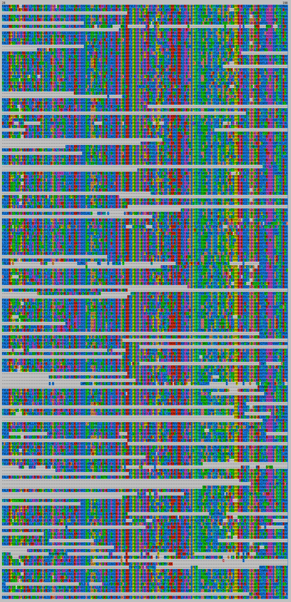

gt6-seq20-res6

> Selected Sequences: 808 /Selected Residues: 303

> Deleted Sequences: 0 /Deleted Residues: 2188

So that was pointless, let's try 90 instead:

gt6-seq90-res6

> Selected Sequences: 800 /Selected Residues: 303

> Deleted Sequences: 8 /Deleted Residues: 2188

Marginally better, lets keep trying

trim-gt6-seq95-res7

> Selected Sequences: 584 /Selected Residues: 303

> Deleted Sequences: 224 /Deleted Residues: 2188

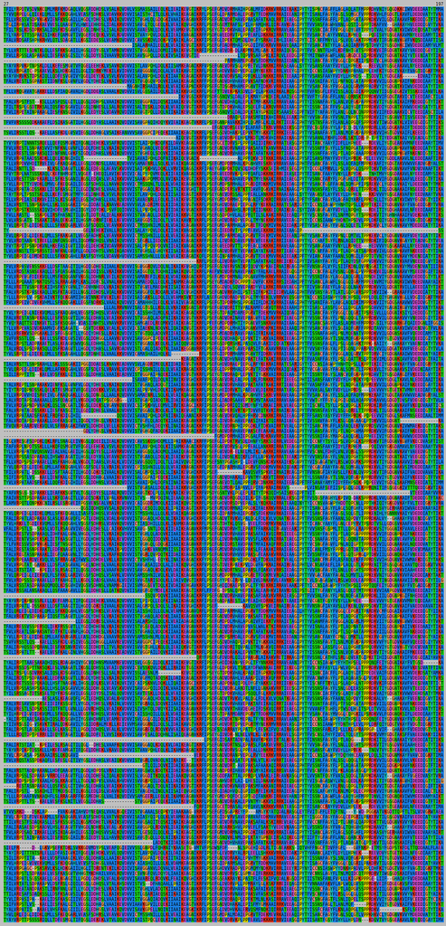

# Tree building

We'll make fast trees (not so acurate, no bootstraps, but fast) (optional) and we'll make "propper trees" using the amazing `iqtree`

## fasttree

```bash
rm -rf ./data/LAR_orthogroup_fasttrees
```

```bash
ls analyses/1kP_LAR_orthogroup_random700_guidev3_fasttrees
```

```bash
for a in data/alignments_trimmed/"$inseq"_aligned*.fasta
do echo "making a fasttree of file $a"
   appendix=$(echo $a | cut -d '/' -f 3- | sed "s/$inseq\_//" | sed "s/.fasta//")
   echo $appendix
   if   [ ! -d analyses/"$inseq"_fasttrees ]
   then mkdir  analyses/"$inseq"_fasttrees
   fi
   if   [ ! -d analyses/"$inseq"_fasttrees/"$appendix" ]
   then mkdir  analyses/"$inseq"_fasttrees/"$appendix"
        fasttree -log analyses/"$inseq"_fasttrees/"$appendix"/"$inseq"_"$appendix"_fasttree.log \
                $a \
                > analyses/"$inseq"_fasttrees/"$appendix"/"$inseq"_"$appendix"_fasttree.tree \
                2> analyses/"$inseq"_fasttrees/"$appendix"/"$inseq"_"$appendix"_fasttree.stderr &
    fi
done
```

```bash
tail analyses/"$inseq"_fasttrees/"$appendix"/"$inseq"_"$appendix"_fasttree.log
```

```bash
ls analyses/"$inseq"_fasttrees/"$appendix"/
```

## IQtree

Now let's loop over all made aligments, making a tree. Choose your parameters wisely, this can take a long time

- Are doing a first testrun? Have a look at the -fast option
- No time to wait for propper bootstraps, use the ultrafast bootstrap option, -bb 1000 (Don't believe nodes with less than 95% bootstrap
- Writing for your amazing manuscript? Do propper bootstraps! -b 1000

Model finder, this is the best feature of iqtree. Evolution can happen in a lot of ways, and iqtree takes this into account. Use `-m TEST` to use modelfinder, or `-m MFP` for extended modelfinding (for your publication quality tree). Modelfinder, especially the extended version, can take a long time to calculate. So if you have done it once for a specific alignment, don't do it twice. ;)

Now have a look at these examples and the manual:

### iqtree ultra fast bootstrap

```bash
ls data/alignments_trimmed/"$inseq"_aligned*gt*.fasta
```

```bash
grep 'Best-fit model'  ./analyses/1kP_LAR_orthogroup_random700_guidev3_trees/aligned-mafft-linsi_trim-gt6-seq80/1kP_LAR_orthogroup_random700_guidev3_aligned-mafft-linsi_trim-gt6-seq80_iqtree-bb2000-shalrt2000
```

```bash
iqpendix='iqtree-bb2000-alrt2000'

#for a in data/alignments_trimmed/"$inseq"_aligned*trim*.fasta
for a in data/alignments_trimmed/"$inseq"_aligned*trim-gt4-seq95-res7.fasta
do echo "making a tree of file $a"
   appendix=$(echo $a | cut -d '/' -f 3- | sed "s/$inseq\_//" | sed "s/.fasta//")
   echo $appendix
   if   [ ! -d analyses/"$inseq"_trees ]
   then mkdir  analyses/"$inseq"_trees
   fi
   if   [ ! -d analyses/"$inseq"_trees/"$appendix" ]
   then mkdir  analyses/"$inseq"_trees/"$appendix"
   fi
   if   [ ! -f analyses/"$inseq"_trees/"$appendix"/"$inseq"_"$appendix"_"$iqpendix".tree ]
   then     nice iqtree -s $a \
            -bb 2000 \
            -alrt 2000 \
            -nt AUTO \
            -ntmax 12  \
            -pre analyses/"$inseq"_trees/"$appendix"/"$inseq"_"$appendix"_"$iqpendix" \
            2>  analyses/"$inseq"_trees/"$appendix"/"$inseq"_"$appendix"_"$iqpendix"-b1000 \
            >  analyses/"$inseq"_trees/"$appendix"/"$inseq"_"$appendix"_"$iqpendix" \
            -m MFP && \
            cat analyses/"$inseq"_trees/"$appendix"/"$inseq"_"$appendix"_"$iqpendix".log | mail -s LAR_selectionv1_guidev5 laura.w.dijkhuizen@gmail.com &
   fi
done
```

```
(phylogenetics) (phylogenetics) (phylogenetics) making a tree of file data/alignments_trimmed/1kP_LAR_selectionv1_guide_v5_aligned-mafft-linsi_trim-gt4-seq95-res7.fasta
aligned-mafft-linsi_trim-gt4-seq95-res7
[1] 17056
(phylogenetics)
```

```bash
iqpendix='iqtree-b200'

#for a in data/alignments_trimmed/"$inseq"_aligned*trim*.fasta
for a in data/alignments_trimmed/"$inseq"_aligned*trim-gt4-seq95-res7.fasta
do echo "making a tree of file $a"
   appendix=$(echo $a | cut -d '/' -f 3- | sed "s/$inseq\_//" | sed "s/.fasta//")
   echo $appendix
   if   [ ! -d analyses/"$inseq"_trees ]
   then mkdir  analyses/"$inseq"_trees
   fi
   if   [ ! -d analyses/"$inseq"_trees/"$appendix" ]
   then mkdir  analyses/"$inseq"_trees/"$appendix"
   fi
   if   [ ! -f analyses/"$inseq"_trees/"$appendix"/"$inseq"_"$appendix"_"$iqpendix".tree ]
   then     nice iqtree -s $a \
            -b 200 \
            -nt AUTO \
            -ntmax 12  \
            -pre analyses/"$inseq"_trees/"$appendix"/"$inseq"_"$appendix"_"$iqpendix" \
            2>  analyses/"$inseq"_trees/"$appendix"/"$inseq"_"$appendix"_"$iqpendix"-b1000 \
            >  analyses/"$inseq"_trees/"$appendix"/"$inseq"_"$appendix"_"$iqpendix" \
            -m LG+R7 && \
            cat analyses/"$inseq"_trees/"$appendix"/"$inseq"_"$appendix"_"$iqpendix".log | mail -s LAR_selectionv1_guidev5 laura.w.dijkhuizen@gmail.com &
   fi
done
```

```
making a tree of file data/alignments_trimmed/1kP_LAR_selectionv1_guide_v5_aligned-mafft-linsi_trim-gt4-seq95-res7.fasta
aligned-mafft-linsi_trim-gt4-seq95-res7
[1] 10412
```

```bash
ls analyses/"$inseq"_trees/aligned*/
```

```
1kP_LAR_selectionv1_guide_v5_aligned-mafft-linsi_trim-gt4-seq95-res7_iqtree-b200
1kP_LAR_selectionv1_guide_v5_aligned-mafft-linsi_trim-gt4-seq95-res7_iqtree-b200-b1000
1kP_LAR_selectionv1_guide_v5_aligned-mafft-linsi_trim-gt4-seq95-res7_iqtree-b200.boottrees
1kP_LAR_selectionv1_guide_v5_aligned-mafft-linsi_trim-gt4-seq95-res7_iqtree-b200.ckp.gz
1kP_LAR_selectionv1_guide_v5_aligned-mafft-linsi_trim-gt4-seq95-res7_iqtree-b200.log
1kP_LAR_selectionv1_guide_v5_aligned-mafft-linsi_trim-gt4-seq95-res7_iqtree-bb2000-alrt2000
1kP_LAR_selectionv1_guide_v5_aligned-mafft-linsi_trim-gt4-seq95-res7_iqtree-bb2000-alrt2000-b1000
1kP_LAR_selectionv1_guide_v5_aligned-mafft-linsi_trim-gt4-seq95-res7_iqtree-bb2000-alrt2000.bionj
1kP_LAR_selectionv1_guide_v5_aligned-mafft-linsi_trim-gt4-seq95-res7_iqtree-bb2000-alrt2000.ckp.gz
1kP_LAR_selectionv1_guide_v5_aligned-mafft-linsi_trim-gt4-seq95-res7_iqtree-bb2000-alrt2000.contree
1kP_LAR_selectionv1_guide_v5_aligned-mafft-linsi_trim-gt4-seq95-res7_iqtree-bb2000-alrt2000.iqtree
1kP_LAR_selectionv1_guide_v5_aligned-mafft-linsi_trim-gt4-seq95-res7_iqtree-bb2000-alrt2000.log
1kP_LAR_selectionv1_guide_v5_aligned-mafft-linsi_trim-gt4-seq95-res7_iqtree-bb2000-alrt2000.mldist
1kP_LAR_selectionv1_guide_v5_aligned-mafft-linsi_trim-gt4-seq95-res7_iqtree-bb2000-alrt2000.model.gz
1kP_LAR_selectionv1_guide_v5_aligned-mafft-linsi_trim-gt4-seq95-res7_iqtree-bb2000-alrt2000.splits.nex
1kP_LAR_selectionv1_guide_v5_aligned-mafft-linsi_trim-gt4-seq95-res7_iqtree-bb2000-alrt2000.treefile
1kP_LAR_selectionv1_guide_v5_aligned-mafft-linsi_trim-gt4-seq95-res7_iqtree-bb2000-alrt2000.uniqueseq.phy
```

```bash
tail -n 20 analyses/"$inseq"_trees/"$appendix"/"$inseq"_"$appendix"_"$iqpendix".log
```

```
Iteration 20 / LogL: -125634.698 / Time: 0h:3m:58s
Finish initializing candidate tree set (20)
Current best tree score: -125320.382 / CPU time: 201.466
Number of iterations: 20
--------------------------------------------------------------------
|               OPTIMIZING CANDIDATE TREE SET                      |
--------------------------------------------------------------------
Estimate model parameters (epsilon = 0.100)
BETTER TREE FOUND at iteration 21: -125311.000
Estimate model parameters (epsilon = 0.100)
BETTER TREE FOUND at iteration 22: -125303.691
Estimate model parameters (epsilon = 0.100)
BETTER TREE FOUND at iteration 23: -125276.323
Estimate model parameters (epsilon = 0.100)
BETTER TREE FOUND at iteration 24: -125273.840
Estimate model parameters (epsilon = 0.100)
BETTER TREE FOUND at iteration 26: -125254.052
Estimate model parameters (epsilon = 0.100)
BETTER TREE FOUND at iteration 30: -125246.818
Iteration 30 / LogL: -125246.818 / Time: 0h:5m:24s (0h:18m:37s left)
```

```bash
grep 'START' analyses/"$inseq"_trees/"$appendix"/"$inseq"_"$appendix"_"$iqpendix".log
```

[output not shown]

[output cut: 24 more lines]

```
===> START BOOTSTRAP REPLICATE NUMBER 65
===> START BOOTSTRAP REPLICATE NUMBER 66
===> START BOOTSTRAP REPLICATE NUMBER 67
===> START BOOTSTRAP REPLICATE NUMBER 68
===> START BOOTSTRAP REPLICATE NUMBER 69
===> START BOOTSTRAP REPLICATE NUMBER 70
===> START BOOTSTRAP REPLICATE NUMBER 71
===> START BOOTSTRAP REPLICATE NUMBER 72
===> START BOOTSTRAP REPLICATE NUMBER 73
===> START BOOTSTRAP REPLICATE NUMBER 74
===> START BOOTSTRAP REPLICATE NUMBER 75
===> START BOOTSTRAP REPLICATE NUMBER 76
===> START BOOTSTRAP REPLICATE NUMBER 77
===> START BOOTSTRAP REPLICATE NUMBER 78
===> START BOOTSTRAP REPLICATE NUMBER 79
```

# tree storage

find the trees in iTOL: https://itol.embl.de/shared/lauradijkhuizen

## Ferns LAR and WannebeLAR clades

We have identified roughly three clades of fern LAR and LAR likes, here I select sequences from fern species that have representative sequences in each of these three clades.

# LAR

UGNK-2002432-Marattia attenuata

MEKP-2009607-Dipteris conjugata

VIBO-2075523-Osmunda javanica

VIBO-2074404-Osmunda javanica

MEKP-2006126-Dipteris conjugata

PNZO-2008392-Culcita macrocarpa

PNZO-2022483-Culcita macrocarpa

MEKP-2104936-Dipteris conjugata

CQPW-2095554-Anemia tomentosa

PNZO-2020054-Culcita macrocarpa

CVEG-2005709-Azolla cf. caroliniana

Azolla filiculoides LAR

Azfi s0197.g057377 characterized LAR

YJJY-2005734-Woodsia scopulina

ZXJO-2003107-Hemionitis arifolia

ZXJO-2003105-Hemionitis arifolia

PIVW-2004875-Ceratopteris thalictroides

PIVW-2004244-Ceratopteris thalictroides

PIVW-2004243-Ceratopteris thalictroides

ZXJO-2004441-Hemionitis arifolia

ZXJO-2004443-Hemionitis arifolia

ZXJO-2004442-Hemionitis arifolia

# WLAR1

CAPN-2038587-Equisetum diffusum

JVSZ-2129506-Equisetum hymale

JVSZ-2001809-Equisetum hymale

JVSZ-2001808-Equisetum hymale

JVSZ-2001810-Equisetum hymale

JVSZ-2001811-Equisetum hymale

UGNK-2017109-Marattia attenuata

UGNK-2021182-Marattia attenuata

MEKP-2006924-Dipteris conjugata

EWXK-2119988-Thyrsopteris elegans

PNZO-2007161-Culcita macrocarpa

PNZO-2007160-Culcita macrocarpa

PNZO-2013494-Culcita macrocarpa

EWXK-2121103-Thyrsopteris elegans

VIBO-2007835-Osmunda javanica

MEKP-2104845-Dipteris conjugata

EWXK-2121424-Thyrsopteris elegans

PNZO-2150800-Culcita macrocarpa

VIBO-2006262-Osmunda javanica

VIBO-2006264-Osmunda javanica

CQPW-2096458-Anemia tomentosa

MEKP-2001942-Dipteris conjugata

CQPW-2014224-Anemia tomentosa

PNZO-2149017-Culcita macrocarpa

EWXK-2024179-Thyrsopteris elegans

EWXK-2022152-Thyrsopteris elegans

PNZO-2026447-Culcita macrocarpa

CVEG-2016335-Azolla cf. caroliniana

CVEG-2016336-Azolla cf. caroliniana

Afi v2 s1241G000110.6 PCBER

Afi v2 s1241G000080.2 IFR

PIVW-2013241-Ceratopteris thalictroides

PIVW-2091514-Ceratopteris thalictroides

ZXJO-2007558-Hemionitis arifolia

YJJY-2003866-Woodsia scopulina

YJJY-2003867-Woodsia scopulina

### WLAR2

MEKP-2105811-Dipteris conjugata

VIBO-2008406-Osmunda javanica

MEKP-2014651-Dipteris conjugata

MEKP-2104929-Dipteris conjugata

CQPW-2024177-Anemia tomentosa

PIVW-2009700-Ceratopteris thalictroides

ZXJO-2008167-Hemionitis arifolia

ZXJO-2008168-Hemionitis arifolia

EWXK-2012291-Thyrsopteris elegans

EWXK-2012289-Thyrsopteris elegans

YJJY-2008533-Woodsia scopulina

UGNK-2006528-Marattia attenuata

ALVQ-2018495-Tmesipteris parva

QVMR-2016059-Psilotum nudum

ALVQ-2000101-Tmesipteris parva

ALVQ-2000100-Tmesipteris parva

ALVQ-2007082-Tmesipteris parva

QVMR-2017404-Psilotum nudum

UGNK-2021731-Marattia attenuata

PNZO-2016614-Culcita macrocarpa

PNZO-2016613-Culcita macrocarpa

QVMR-2013662-Psilotum nudum

ALVQ-2004508-Tmesipteris parva

ALVQ-2004507-Tmesipteris parva

ALVQ-2004506-Tmesipteris parva

EWXK-2000842-Thyrsopteris elegans

EWXK-2000843-Thyrsopteris elegans

EWXK-2000844-Thyrsopteris elegans

UGNK-2020446-Marattia attenuata

MEKP-2101772-Dipteris conjugata

MEKP-2006789-Dipteris conjugata

MEKP-2006790-Dipteris conjugata

```bash
mkdir analyses/WLARs
```

```bash
ls analyses/WLARs
```

```
fernLARs.txt  fernWLAR1.txt  fernWLAR2.txt
```

```bash
wc -l ./analyses/WLARs/fern*LAR*.txt
```

```
  21 ./analyses/WLARs/fernLARs.txt
  36 ./analyses/WLARs/fernWLAR1.txt
  31 ./analyses/WLARs/fernWLAR2.txt
  88 total
```

```bash
#sed -i 's/ /_/g' ./analyses/WLARs/fern*LAR*.txt
```

```bash
/opt/rnaseq/bin/extract_sequence_by_id.pl --ID=./analyses/WLARs/fernLARs.txt  \
                                          --fileformat=txt \
                                          --sequences=./data/1kP_LAR_selectionv1_guide_v5.fasta \
                                          --outfile=./analyses/WLARs/fernLARs.fasta
```

```bash
/opt/rnaseq/bin/extract_sequence_by_id.pl --ID=./analyses/WLARs/fernWLAR1.txt  \
                                          --fileformat=txt \
                                          --sequences=./data/1kP_LAR_selectionv1_guide_v5.fasta \
                                          --outfile=./analyses/WLARs/fernWLAR1.fasta
```

```bash
/opt/rnaseq/bin/extract_sequence_by_id.pl --ID=./analyses/WLARs/fernWLAR2.txt  \
                                          --fileformat=txt \
                                          --sequences=./data/1kP_LAR_selectionv1_guide_v5.fasta \
                                          --outfile=./analyses/WLARs/fernWLAR2.fasta
```

```bash
grep '>' -c ./analyses/WLARs/fern*LAR*.fasta
```

```
./analyses/WLARs/fernLARs.fasta:20
./analyses/WLARs/fernWLAR1.fasta:34
./analyses/WLARs/fernWLAR2.fasta:32
```

```bash
diff <(sort analyses/WLARs/fernLARs.txt) <(grep '>' analyses/WLARs/fernLARs.fasta | tr -d '>' | sort)
```

```
1,2d0
< Azfi_s0197.g057377 (characterized LAR)
< Azolla filiculoides LAR
```

```bash
diff <(sort analyses/WLARs/fernWLAR1.txt) <(grep '>' analyses/WLARs/fernWLAR1.fasta | tr -d '>' | sort)
```

```
1,2d0
< Afi_v2_s1241G000080.2 (IFR)
< Afi_v2_s1241G000110.6 (PCBER)
```

```bash
diff <(sort analyses/WLARs/fernWLAR2.txt) <(grep '>' analyses/WLARs/fernWLAR2.fasta | tr -d '>' | sort)
```

```bash
cat analyses/WLARs/fernLARs.fasta | sed 's/^>/>LAR_/g'>  analyses/WLARs/fernLARclades.fasta
cat analyses/WLARs/fernWLAR1.fasta | sed 's/^>/>WLAR1_/g'>> analyses/WLARs/fernLARclades.fasta
cat analyses/WLARs/fernWLAR2.fasta | sed 's/^>/>WLAR2_/g'>> analyses/WLARs/fernLARclades.fasta
```

```bash
head ./analyses/WLARs/fernLARclades.fasta
```

```
>LAR_PIVW-2004875-Ceratopteris_thalictroides
MGFKSKVLIFGGTGYIGKHIVRASVAEGHPTSVFVRSSTLQTKAELVGSFKELGVSIIEG…
>LAR_YJJY-2005734-Woodsia_scopulina
MGGKSRVLIFGATGYIGKHIARASVAEGHPTSVFVRPSTLQTKAELVESFKALGITFVEG…
>LAR_MEKP-2006126-Dipteris_conjugata
MGLKSRVLIIGATGYIGKHVARACVAQGHPTSILIRPPTLISKKELVDSFTELGISFIHG…
>LAR_ZXJO-2004443-Hemionitis_arifolia
MGVKGRVLIFGGTGYIGRHIVRASVAEGHPTSVFIRSSTLQSKAELVSSFKELGVSFVEG…
>LAR_PNZO-2008392-Culcita_macrocarpa
KSRVLIIGATGYIGKHVARASIAEGHSTSILVRPSTLTSKAELVESFKSLGITLVEGSLD…
```

then add these

> WLAR1_Afi_v2_s1241G000080.2 MAGGEGESKRVLVLGATGYIGKFIALAGPSLGHPTFALIRPSTIASKPDIVQSLQSAGITILQGSLDDHESLVAAFKQVDVVISAVGGAQLKDQLKVLEA IKEAGTIKRFIPSEFGNDVDRTHSLEPAQSLFKGKIEVRRSIEDAGIPYTYVVSNGFAGYFLSNLLQEGHTSPPRDKVTIYGSGDVKAIAVHEEDIGTYT IKAAFDPRALNKTLHIRPPANIITLNELVDKWEKKIGKTLEKITVTEEEFVKKIESMSLNPFFFSLDLFSLSFVCFLLVKHSTDVMSARCRYSISREHFS IYFAWHCLQRGANKFRAWTQ WLAR1_Afi_v2_s1241G000110.6 MIHPSIHSIMHLDCDDSFIPSLHVPQSQQTQSSSMNDSADRTWESRERETDRQRGMAGGGEGESKRILILGATGYIGKFIALAGPSLGHPTFALIRPSTI ASKPDLVQSLRSAGISILQGSLDDHESLVAAFKQVDVVISAVGEAQLKDQLKILDAIKEVGTIKRFIPSEFGSDVNHSQGLGPAQSLFKAKVEIRRSIED AGIPYMYVVANGFAGYFLSSLLQEGHTSPPRDKVTIYGSGDVKVIAVYEEDVGTYTIKAAFDPRTLNKTLHIRPPANIVTFNELVDKWEKKIGKSLEKIT VTEEEFVKKIEGTPFPGNLFLSLLHGIVFKGDQTNFELGPNDVEATSLYPDVKYTSVDDYLDRFV LAR_Azolla filiculoides LAR MGVKSRVLIIGATGYIGKHVARASVAEGHPTSILIRPSTLTTKAELVTSFKDLGITLVEGS LDDHAGLVAAIKEVDVVISTVGGPAIPEQEKIIAAIKEAGNVLRFLPSEFGNDVDHAK ALEPVNTMYGKKVTIRRKIEEAGIPYTYISSNAFAGYSLSNLVQFGKPSPPRDKVTIYG SGDAKAIFLKEEDIGLFTIKTIDDPRTLNKIVYLRPPGNILSVNEVVSLWESKIGAKLER EYVSEEDMIVLIKTSPIPKNIVLATVHNIFVRGDQYNFEIGEKGVEASTLYPDVKYTTAS EYLDKFV LAR_Azfi_s0197.g057377 MGVKSRVLIIGATGYIGKHVARASVAEGHPTSILIRPSTLTTKAELVTSFKDLGITLVEGSLDDHAGLVA AIKEVDVSSRPSVGLPSPSKRRSLLLLKKQGMFLPSEFGNDVDHAKALEPVNTMYGKKVTIRRKIEEAGI PYTYISSNAFAGYSLSNLVQFGKPSPPRDKVTIYGSGDAKAIFLKEEDIGLFTIKTIDDPRTLNKIVYLR PPGNILSVNEVVSLWESKIGAKLEREYVSEEDMIVLIKTSPIPKNIVLATVHNIFVRGDQYNFEIGEKGV EASTLYPDVKYTTASEYLDKFV

```bash
conda activate phylogenetics
linsi --thread 6 analyses/WLARs/fernLARclades.fasta > analyses/WLARs/fernLARclades_aligned-mafft-linsi.fasta
conda deactivate
```

[output not shown]

[output cut: 11 more lines]

```
6 thread(s)


Strategy:
 L-INS-i (Probably most accurate, very slow)
 Iterative refinement method (<16) with LOCAL pairwise alignment information

If unsure which option to use, try 'mafft --auto input > output'.
For more information, see 'mafft --help', 'mafft --man' and the mafft page.

The default gap scoring scheme has been changed in version 7.110 (2013 Oct).
It tends to insert more gaps into gap-rich regions than previous versions.
To disable this change, add the --leavegappyregion option.

(phylogenetics)
```

```bash
mkdir ./analyses/WLARs/fernLARclades_tree
nice iqtree -s ./analyses/WLARs/fernLARclades_aligned-mafft-linsi.fasta \
            -b 1000  \
            -nt AUTO \
            -ntmax 6  \
            -pre ./analyses/WLARs/fernLARclades_tree/fernLARclades_aligned-mafft-linsi_iqtree-b1000 \
            2> ./analyses/WLARs/fernLARclades_tree/fernLARclades_aligned-mafft-linsi_iqtree-b1000.stderr \
            >  ./analyses/WLARs/fernLARclades_tree/fernLARclades_aligned-mafft-linsi_iqtree-b1000.stdout \
            -m 'JTTDCMut+I+G4' && \
            cat ./analyses/WLARs/fernLARclades_tree/fernLARclades_aligned-mafft-linsi_iqtree-b1000.log | mail -s WLAR_tree laura.w.dijkhuizen@gmail.com &
```

```
mkdir: cannot create directory ‘./analyses/WLARs/fernLARclades_tree’: File exists
[2]+  Done                    nice iqtree -s ./analyses/WLARs/fernLARclades_aligned-mafft-linsi.fasta -bb 2000 -alrt 2000 -nt AUTO -ntmax 12 -pre ./analyses/WLARs/fernLARclades_tree/fernLARclades_aligned-mafft-linsi_iqtree-bb2000-alrt2000 -m MFP 2> ./analyses/WLARs/fernLARclades_tree/fernLARclades_a…
[2] 18561
```

```bash
tail ./analyses/WLARs/fernLARclades_tree/fernLARclades_aligned-mafft-linsi_iqtree-b1000.stdout -n 40
```

```
Estimate model parameters (epsilon = 0.100)
1. Initial log-likelihood: -21555.439
2. Current log-likelihood: -21207.645
3. Current log-likelihood: -21196.585
4. Current log-likelihood: -21194.970
5. Current log-likelihood: -21194.577
6. Current log-likelihood: -21194.457
Optimal log-likelihood: -21194.413
Proportion of invariable sites: 0.015
Gamma shape alpha: 1.542
Parameters optimization took 6 rounds (2.019 sec)
Computing ML distances based on estimated model parameters... 2.679 sec
Computing BIONJ tree...
0.006 seconds
Log-likelihood of BIONJ tree: -21152.638
--------------------------------------------------------------------
|             INITIALIZING CANDIDATE TREE SET                      |
--------------------------------------------------------------------
Generating 98 parsimony trees... 5.373 second
Computing log-likelihood of 98 initial trees ... 13.320 seconds
Current best score: -21100.602

Do NNI search on 20 best initial trees
Estimate model parameters (epsilon = 0.100)
BETTER TREE FOUND at iteration 1: -21066.366
Estimate model parameters (epsilon = 0.100)
BETTER TREE FOUND at iteration 9: -21065.968
Iteration 10 / LogL: -21076.774 / Time: 0h:0m:35s
Estimate model parameters (epsilon = 0.100)
BETTER TREE FOUND at iteration 11: -21065.300
Iteration 20 / LogL: -21078.465 / Time: 0h:0m:49s
Finish initializing candidate tree set (20)
Current best tree score: -21065.300 / CPU time: 46.436
Number of iterations: 20
--------------------------------------------------------------------
|               OPTIMIZING CANDIDATE TREE SET                      |
--------------------------------------------------------------------
Estimate model parameters (epsilon = 0.100)
BETTER TREE FOUND at iteration 23: -21065.040
Iteration 30 / LogL: -21065.089 / Time: 0h:1m:8s (0h:3m:41s left)
```